# Timeline

Anthony Davidson

# Sorting out times and datas

This is a nasty task in any project however it is important to understand how much data we have and how that might be changing as we are developing and publishing the results. To check this we can recreate the date folder and run a set of functions over this until we get a useable variable.

```
## [1] "2010-09-10 22:20:00 UTC"
```

# Summarised outcome

This report captures a Exposure.location and suburb. The location information needs to be added to this. We have done that in another process and this work takes the following variables and converts the outcome into a visualiable set of location variables:

```r
dat <- read.csv("../data/last.csv")

glimpse(dat)
```

```
## Rows: 441
## Columns: 12
## $ Status            <chr> "", "New", "New", "New", "New", "New", "", "", "", "~
## $ Exposure.Location <chr> "Woolworths Charnwood", "Priceline Pharmacy Gungahli~
## $ Street            <chr> "25-30 Charnwood Place", "126/43 Hibberson Street", ~
## $ Suburb            <chr> "Charnwood", "Gungahlin", "Gungahlin", "Gungahlin", ~
## $ Date              <chr> "30/08/2021 - Monday", "30/08/2021 - Monday", "30/08~
## $ Arrival.Time      <chr> "7:00am", "12:20pm", "12:40pm", "12:50pm", "1:25pm",~
## $ Departure.Time    <chr> "8:20am", "1:20pm", "1:30pm", "2:00pm", "1:38pm", "2~
## $ Contact           <chr> "Casual", "Casual", "Monitor", "Casual", "Casual", "~
## $ lat               <dbl> -35.20453, -35.18568, -35.18535, -35.18664, -35.3444~
## $ lon               <dbl> 149.0329, 149.1367, 149.1362, 149.1368, 149.0872, 14~
## $ doubles           <chr> "", "", "", "", "", "", "", "", "", "", "", "", "", ~
## $ moved             <lgl> FALSE, FALSE, FALSE, FALSE, FALSE, FALSE, FALSE, FAL~
```

```r
# dat$Date <- as.Date(lubridate::dmy(dat$Date))
dat$caseS <- dat$Arrival.Time
dat$caseE <- dat$Departure.Time

# ampm <- ifelse(dat$caseS == str_detect("am"), dat$caseAM, dat$casePM)
# 30/08/2021 - Monday
# library(tidyverse)
# # mutate(dat,
#        dat$Dayall = str_split(dat$Date, " - ", n = 2)
#        for(i in 1:length(dat$Dayall)){
#          dat$DayDate[i] <-  dat$Dayall[[i]][2]
#          dat$dateCase[i] <-  dat$Dayall[[i]][1]
#        }
#
#
       dat$dateonly <- as.Date(lubridate::dmy(dat$Date))
#
    dat$datetimeS <- flipTime::AsDateTime(paste0(dat$dateonly," ", dat$Arrival.Time))

      dat$datetimeE <- flipTime::AsDateTime(paste0(dat$dateonly," ", dat$Departure.Time))

              glimpse(dat)
```

```
## Rows: 441
## Columns: 17
## $ Status            <chr> "", "New", "New", "New", "New", "New", "", "", "", "~
## $ Exposure.Location <chr> "Woolworths Charnwood", "Priceline Pharmacy Gungahli~
## $ Street            <chr> "25-30 Charnwood Place", "126/43 Hibberson Street", ~
## $ Suburb            <chr> "Charnwood", "Gungahlin", "Gungahlin", "Gungahlin", ~
## $ Date              <chr> "30/08/2021 - Monday", "30/08/2021 - Monday", "30/08~
## $ Arrival.Time      <chr> "7:00am", "12:20pm", "12:40pm", "12:50pm", "1:25pm",~
## $ Departure.Time    <chr> "8:20am", "1:20pm", "1:30pm", "2:00pm", "1:38pm", "2~
## $ Contact           <chr> "Casual", "Casual", "Monitor", "Casual", "Casual", "~
## $ lat               <dbl> -35.20453, -35.18568, -35.18535, -35.18664, -35.3444~
## $ lon               <dbl> 149.0329, 149.1367, 149.1362, 149.1368, 149.0872, 14~
## $ doubles           <chr> "", "", "", "", "", "", "", "", "", "", "", "", "", ~
## $ moved             <lgl> FALSE, FALSE, FALSE, FALSE, FALSE, FALSE, FALSE, FAL~
## $ caseS             <chr> "7:00am", "12:20pm", "12:40pm", "12:50pm", "1:25pm",~
## $ caseE             <chr> "8:20am", "1:20pm", "1:30pm", "2:00pm", "1:38pm", "2~
## $ dateonly          <date> 2021-08-30, 2021-08-30, 2021-08-30, 2021-08-30, 202~
## $ datetimeS         <dttm> 2021-08-30 07:00:00, 2021-08-30 12:20:00, 2021-08-3~
## $ datetimeE         <dttm> 2021-08-30 08:20:00, 2021-08-30 13:20:00, 2021-08-3~
```

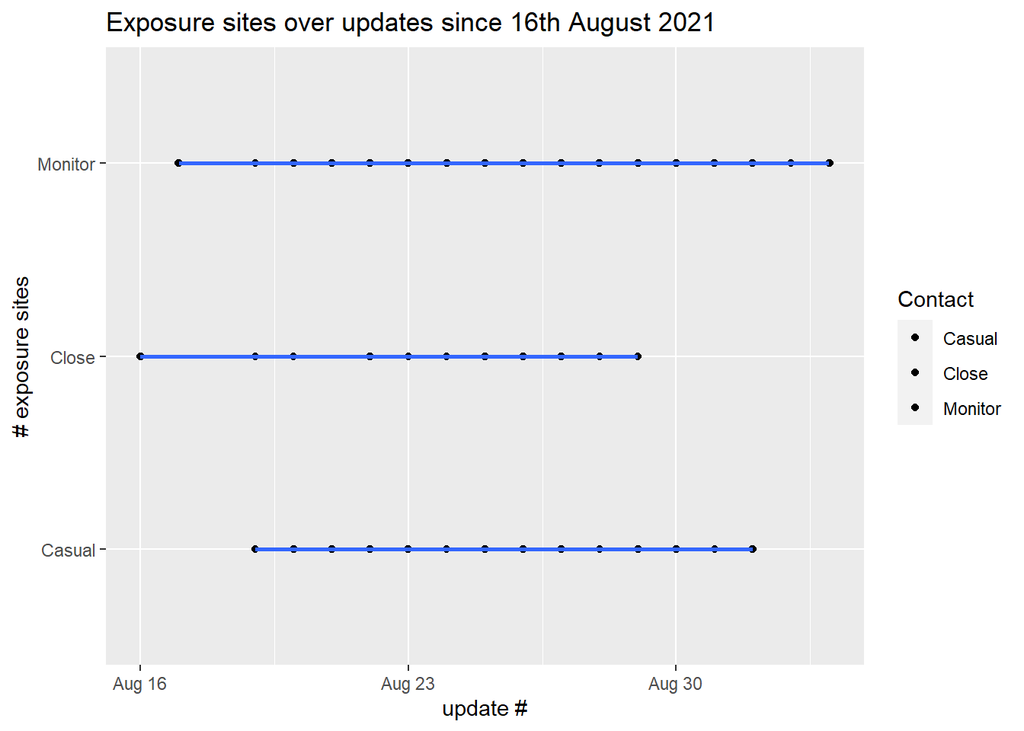

```r
      # select time levedata()

  datTimeSumms <-   dat %>%
        select(dateonly, datetimeS, datetimeE, Suburb, Status, Contact, lat, lon) %>%
    mutate(monthF = lubridate::month(dateonly),
           weekF = lubridate::week(dateonly),
           dayF = lubridate::day(dateonly),
           daysteps = paste0(weekF, dayF))


  ggplot(datTimeSumms, aes(x= dateonly, y= Contact))+
        geom_jitter(aes(fill=Contact, group = daysteps),height = 0, width=0.01)+
    geom_smooth() +
  xlab("update #")+
  ylab("# exposure sites")+
  # facet_wrap(~weekF) +
  ggtitle("Exposure sites over updates since 16th August 2021")
```

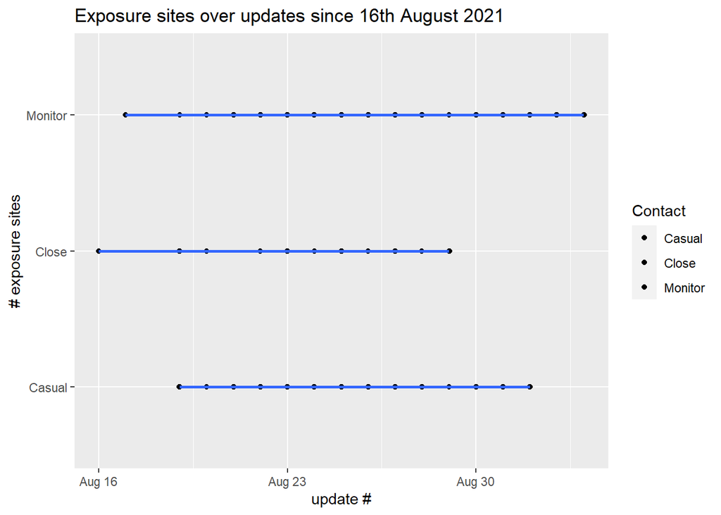

```r
  # ?geom_bar

    ggplot(datTimeSumms, aes(x= dateonly, y= Contact))+
        geom_jitter(aes(fill=Contact, group = daysteps),height = 0, width=0.01)+
    geom_smooth() +
  xlab("update #")+
  ylab("# exposure sites")+
  # facet_wrap(~Contact) +
  ggtitle("Exposure sites over updates since 16th August 2021")
```

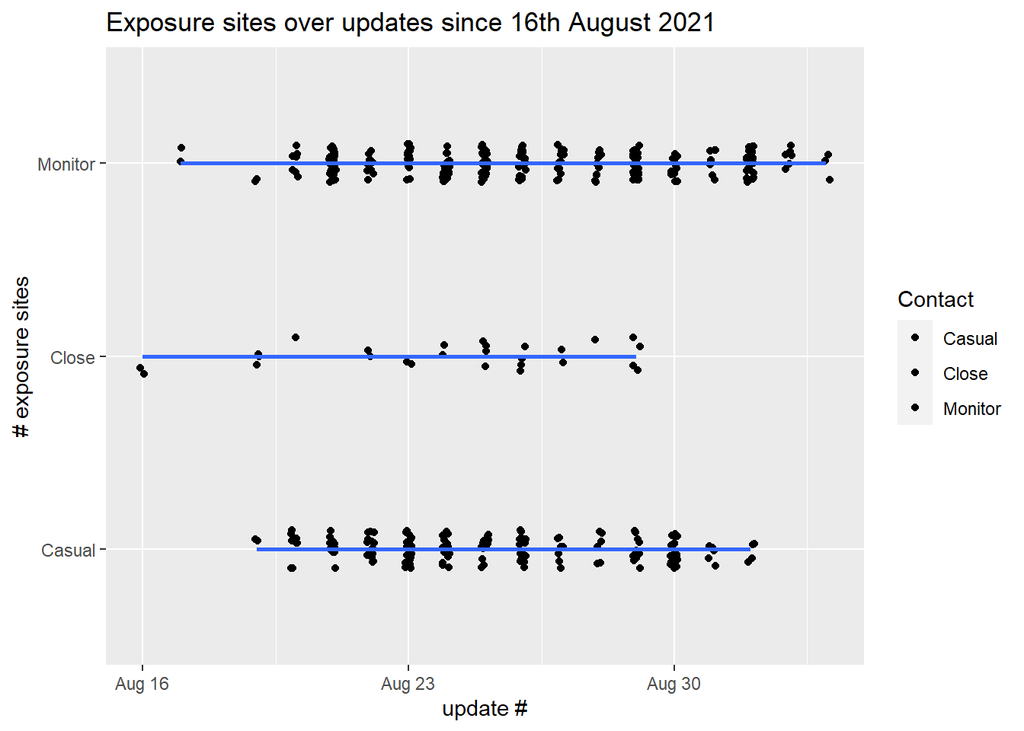

```r
      ggplot(datTimeSumms, aes(x= dateonly, y= Contact))+
        geom_jitter(aes(fill=Contact, group = daysteps),height = 0.1, width=0.1)+
    geom_smooth() +
  xlab("update #")+
  ylab("# exposure sites")+
  # facet_wrap(~weekF) +
  ggtitle("Exposure sites over updates since 16th August 2021")
```

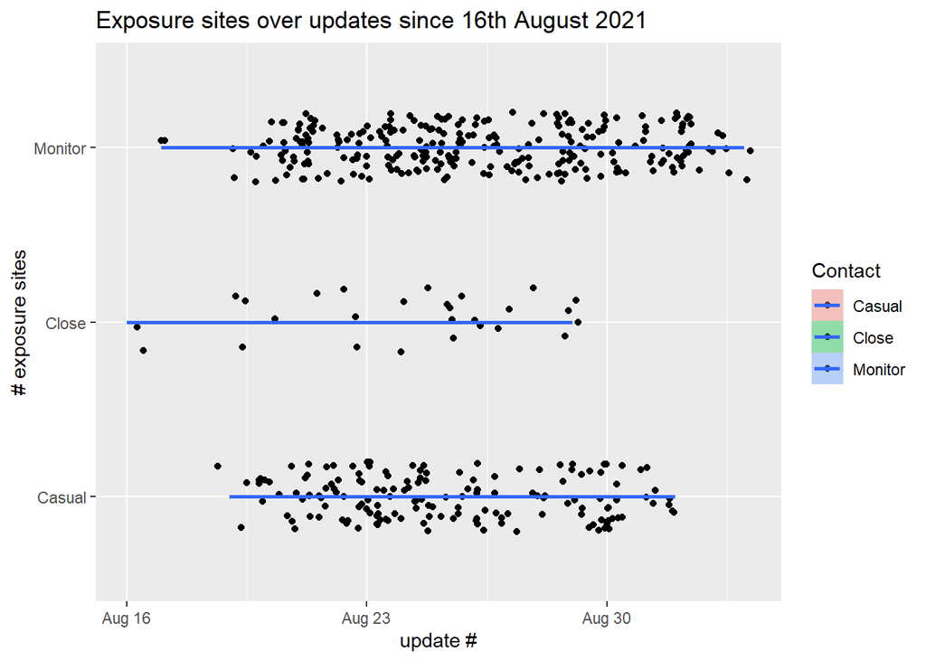

```r
            ggplot(datTimeSumms, aes(x= dateonly, y= Contact))+
        geom_jitter(aes(fill=Contact, group = daysteps),height = 0.2, width=0.5)+
    geom_smooth(aes(fill=Contact, group = Contact)) +
  xlab("update #")+
  ylab("# exposure sites")+
  # facet_wrap(~weekF) +
  ggtitle("Exposure sites over updates since 16th August 2021")
```

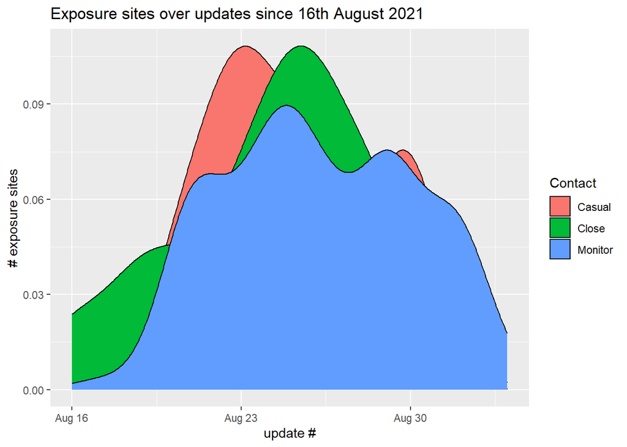

```r
                 ggplot(datTimeSumms, aes(x= dateonly, group= Contact))+
        # geom_jitter(aes(fill=Contact, group = daysteps),height = 0.2, width=0.5)+
                   geom_density(aes(group = Contact,fill=Contact)) +
    # geom_smooth() +
  xlab("update #")+
  ylab("# exposure sites")+
  # facet_wrap(~weekF) +
  ggtitle("Exposure sites over updates since 16th August 2021")
```

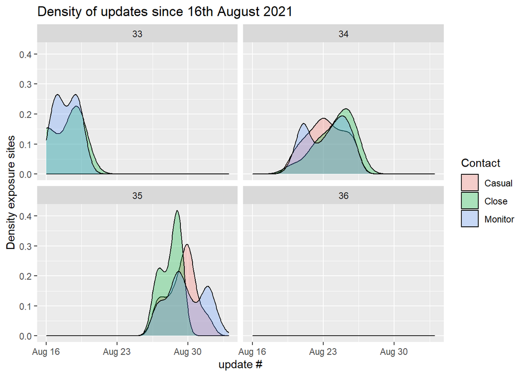

```r
                      ggplot(datTimeSumms, aes(x = dateonly, group = Contact))+
        # geom_jitter(aes(fill=Contact, group = daysteps),height = 0.2, width=0.5)+
                   geom_density(aes(group = Contact, fill = Contact), alpha = 0.3)+
    # geom_smooth() +
  xlab("update #")+
  ylab("Density exposure sites")+
  facet_wrap(~weekF) +
  ggtitle("Density of updates since 16th August 2021")
```

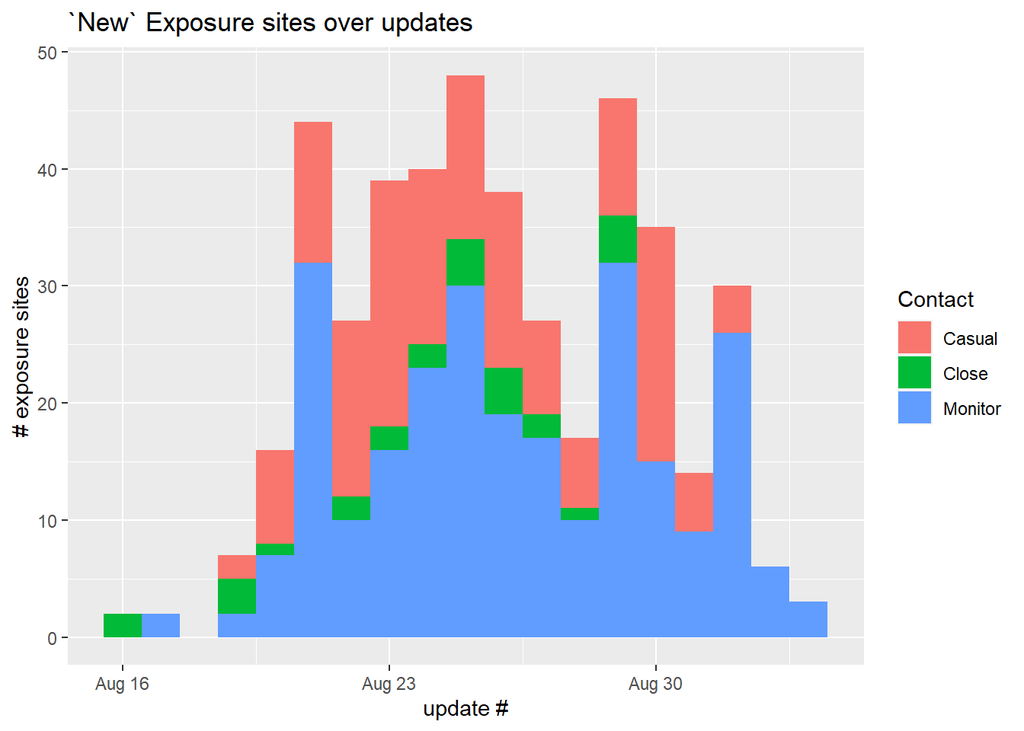

```r
                      # datDY <- dygraphs::


library(dygraphs)
library(xts)          # To make the convertion data-frame / xts format
library(tidyverse)
library(lubridate)
# Read the data (hosted on the gallery website)
# data <- read.table("https://python-graph-gallery.com/wp-content/uploads/bike.csv", header=T, sep=",") %>% head(300)

# Check type of variable

 datTimeSumms1 <- datTimeSumms %>%
   group_by(Contact, dateonly) %>%
   tally() %>%
   ungroup(.)


ggplot(datTimeSumms1, aes(x=dateonly,y=n, group = Contact))+
  geom_bar(stat="identity", position = "stack", width=1, aes(fill=Contact))+
  xlab("update #")+
  ylab("# exposure sites")+
  ggtitle("`New` Exposure sites over updates")
```

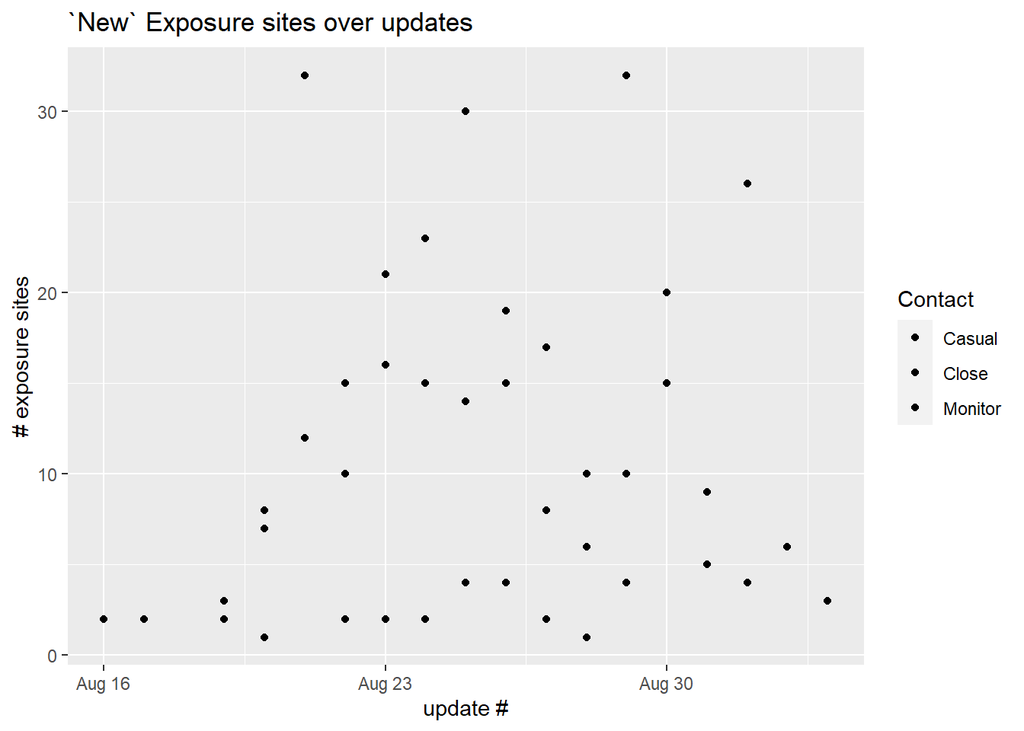

```r
ggplot(datTimeSumms1, aes(x=dateonly,y=n, group = Contact))+
  geom_point(aes(fill=Contact))+
  xlab("update #")+
  ylab("# exposure sites")+
  ggtitle("`New` Exposure sites over updates")
```

- Exposure.location
- Suburb
- Date

```r
#  datTimeSumms1$dateonly
#
# # Since my time is currently a factor, I have to convert it to a date-time format!
# datTimeSumms1$dateonly <- ymd_hms(datTimeSumms1$dateonly)
#
#
#  # Then you can create the xts necessary to use dygraph
#   don <- xts(x = datTimeSumms1$datetime, order.by = datTimeSumms1$datetime, factor(datTimeSumms1$Contact))
# ?xts
#
# Then you can create the xts necessary to use dygraph
  don <- xts(x = datTimeSumms1$n, order.by = datTimeSumms1$dateonly, factor(datTimeSumms1$Contact))

?xts
```

```
## starting httpd help server ... done
```

```r
# Finally the plot
p <- dygraph(don, group = datTimeSumms1$Contact) %>%
  dyOptions(labelsUTC = TRUE, fillGraph=TRUE, fillAlpha=0.1, drawGrid = FALSE, colors="#D8AE5A") %>%
  dyRangeSelector() %>%
  dyCrosshair(direction = "vertical") %>%
  dyHighlight(highlightCircleSize = 5, highlightSeriesBackgroundAlpha = 0.2, hideOnMouseOut = FALSE)  %>%
  dyRoller(rollPeriod = 1)

p
```

[interactive chart not shown]

```r
# save the widget
# library(htmlwidgets)
# saveWidget(p, file=paste0( getwd(), "/HtmlWidget/dygraphs318.html"))
# Examples
# data(sample_matrix)
# sample.xts <- as.xts(sample_matrix, descr='my new xts object')
#
# class(sample.xts)
# str(sample.xts)
#
# head(sample.xts)  # attribute 'descr' hidden from view
# attr(sample.xts,'descr')
#
# sample.xts['2007']  # all of 2007
# sample.xts['2007-03/']  # March 2007 to the end of the data set
# sample.xts['2007-03/2007']  # March 2007 to the end of 2007
# sample.xts['/'] # the whole data set
# sample.xts['/2007'] # the beginning of the data through 2007
# sample.xts['2007-01-03'] # just the 3rd of January 2007

x <- xts(matrix(1:(9*6),nc=6),
         order.by=as.Date(13000,origin="1970-01-01")+1:9,
         a1='my attribute')

xtsAttributes(x)
```

```
## $a1
## [1] "my attribute"
```

```r
xtsAttributes(x) <- list(a2=2020)

xtsAttributes(x)
```

```
## $a1
## [1] "my attribute"
##
## $a2
## [1] 2020
```

```r
xtsAttributes(x) <- list(a1=NULL)
xtsAttributes(x)
```

```
## $a2
## [1] 2020
```

#### COntact time lengths

```r
timingList <- data.frame(dat$caseS, dat$caseE)
# write.csv(timingList, "../data/testTIMS.csv")

# , dat$caseS -dat$caseE)
```

```r
#########function 1 ####################
fileFiles_function <- function(filesiwant){
  allfiles <- list.files(filesiwant, pattern=c("table_", ".csv"), full.names = TRUE)
  return(allfiles)
}
# Exposure sites per Update for august amd sept
filesiwant <- c("./data/allfiles/August/", "../data/allfiles/September/")

allfiles <- suppressWarnings(fileFiles_function(filesiwant = filesiwant))
res <- data.frame(update=NA, date=NA,locations=NA, contact=NA,nsites=NA )
cc<-1

for(i in 1:length(allfiles)){

  dd <- allfiledat[[i]]
  tt <- table(dd$Contact)

  if (length(tt)>0) {
  for (ii in 1:length(tt))
    {
    res[cc, 1] <- i
    res[cc,2] <- (substr(dd$Date[i], 1,10))
    res[cc,3] <- nrow(dd)
    res[cc,4] <- names(tt)[ii]
    res[cc,5] <- tt[ii]
    cc <- cc+1
    }
  }
}


res <- res[!res$contact=="Investigation information",]
res <- res[!res$contact=="Investigation location",]
res$contact <- factor(res$contact, levels=c("Close", "Casual","Monitor"))


res <- res[order(res$contact),]
cols <- c( "red", "yellow","blue")[as.numeric(res$contact)]

ggplot(res, aes(x=update,y=nsites))+geom_bar(stat="identity", position = "stack", width=1, aes(fill=contact))+
  xlab("update #")+
  ylab("# exposure sites")+
  ggtitle("`New` Exposure sites over updates")
```

## Looks like?

Data stored as list of csvs in rds file called raw_rds

#### Basic points

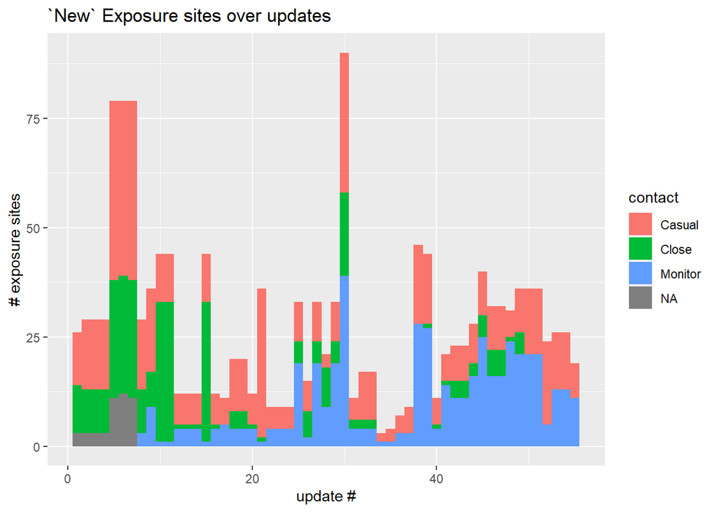

```r
#csvs generated from
# £these need checking
# source("R/resAugustScript.R")
# and
# source("R/resSeptemberscript.R")

#new entries rather than accumulation of cases held by ACT
resA <- read.csv('../data/resAugust.csv')
resS <- read.csv('../data/resSeptember.csv')

resS<- resS %>%
  mutate(update = max(resA$update)+ update)

res <- bind_rows(resA, resS)

ggplot(res, aes(x=update,y=nsites))+
  geom_bar(stat="identity", position = "stack", width=1, aes(fill=contact))+
  xlab("update #")+
  ylab("# exposure sites")+
  ggtitle("`New` Exposure sites over updates")
```

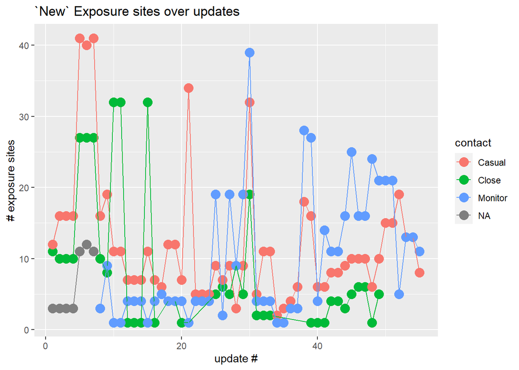

```r
ggplot(res,aes(x=update,y=nsites, group = contact,fill=contact, col = contact))+
  geom_point(size=4)+
  geom_line()+
  xlab("update #")+
  ylab("# exposure sites")+
  ggtitle("`New` Exposure sites over updates")
```

[figure not shown]

## Time is interesting

length of time: start and end time